# Option B — an estimate for a defined area

06 October 2026

**Cowichan Estuary eelgrass — worked example**

> ⚠️ **Teaching example.** The reporting boundary in this report is **hypothetical** — drawn to show how the calculation works, not a mapped meadow. The area, the total and anything that depends on them describe no real place.

## 1. The question

What might the three cores imply for sediment organic carbon across an eelgrass area at Cowichan? (Teaching example: the boundary is hypothetical.)

## 2. Area, habitat and sampling

| Area and habitat | Cowichan Estuary, British Columbia — eelgrass (Zostera marina) sediment |
| --- | --- |
| Reporting boundary | cowichan_HYPOTHETICAL_boundary.csv — 6.6 ha (**hypothetical**) |
| Survey dates | Not given in the compiled dataset (see Douglas et al. 2022) |
| Sampling design | Three stations chosen by the original study to be representative of the meadow (not randomly placed) |
| Sampling unit | one plot (100 m²); cores sharing a Plot ID are averaged first |
| Independent sampling units | 3 (from 3 complete cores) |
| Data source | Douglas, Schuerholz & Juniper (2022), Frontiers in Marine Science 9:857586, as compiled in Janousek et al. (2025), doi:10.25573/serc.28127486 |

**Exploratory** — the cores were not placed with known selection probabilities (for example, chosen by the team or by an earlier study). The mean and total are a reasonable first description, but there is no defensible confidence interval, so none is given.

## 3. The estimate — 0–15 cm, fully measured

**Sediment organic carbon** only. This is a stock — the carbon in the sediment now — not a rate of accumulation and not removal of carbon from the atmosphere. Every core reached 15 cm, so this figure is **measured**: nothing below the base of any core is in it.

**Mean 14.6 Mg C/ha over 6.6 ha: about 96 Mg C in the top 15 cm of sediment (hypothetical area). Range among the 3 sampling units: 12.1–17.1 Mg C/ha. This range is descriptive; it is not a confidence interval.**

Sampling units, 0–15 cm (Mg C/ha)

| Unit | Stratum | Cores | Measured | Estimated | Total |
| --- | --- | --- | --- | --- | --- |
| S5 | SG | 1 | 17.1 | 0.0 | 17.1 |
| S6 | SG | 1 | 12.1 | 0.0 | 12.1 |
| S7 | SG | 1 | 14.5 | 0.0 | 14.5 |

**What the interval includes.** No interval is given for this design. A confidence interval assumes the sampling units were placed at random; these were not, so an interval calculated from them would not tell you how close the mean is to the area’s true value.

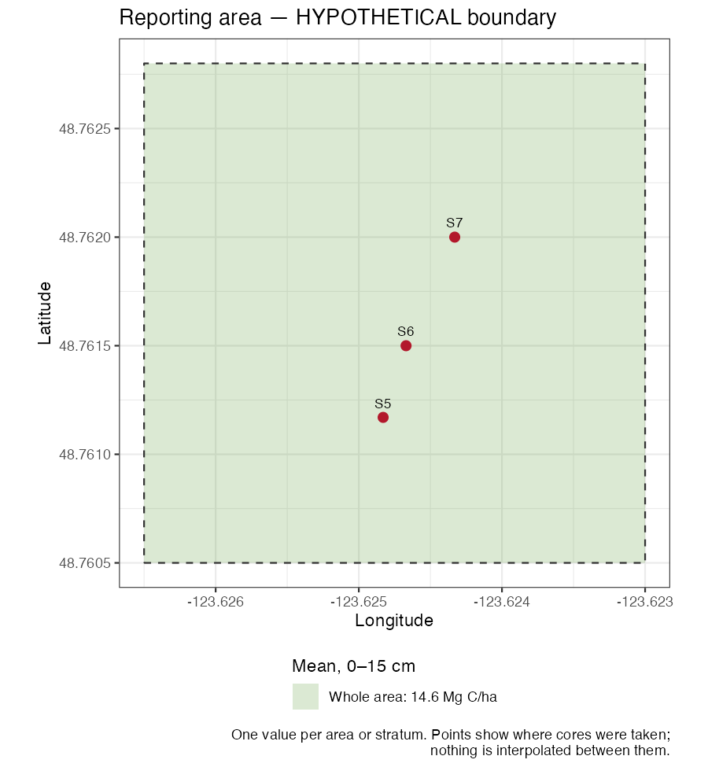

The map shows the reporting area, where the cores were taken and one value per area or stratum. Nothing is mapped between the points: the estimate is an area average, not a map of where the carbon is.

## 4. A deeper scenario — 0–30 cm, partly estimated

> **Scenario, not a measurement.** The cores stop above 30 cm, so **38%** of this figure is estimated below them (see section 5). Report it only alongside the measured 0–15 cm figure, and say how much was estimated.

**Mean 33.7 Mg C/ha over 6.6 ha: about 221 Mg C in the top 30 cm of sediment (hypothetical area). Range among the 3 sampling units: 27.4–41.2 Mg C/ha. This range is descriptive; it is not a confidence interval.**

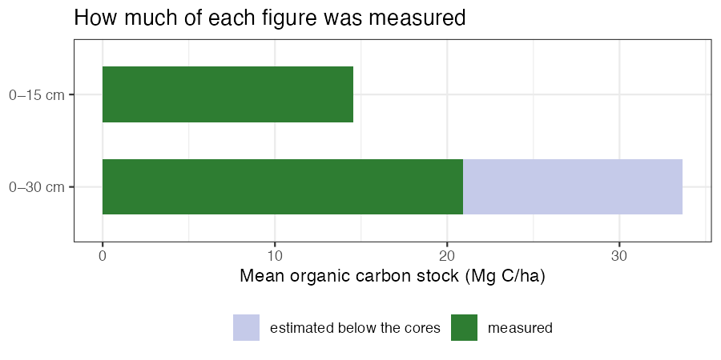

**Depths not reported.** Following Janousek et al. (2025), a stock is reported to 30 cm only for cores at least 20 cm long, to 50 cm for cores at least 35 cm and to 100 cm for cores at least 75 cm:

- 0–50 cm — needs every core to reach 35 cm; too short: COW-S5, COW-S6, COW-S7.
- 0–100 cm — needs every core to reach 75 cm; too short: COW-S5, COW-S6, COW-S7.

## 5. How was depth estimated?

1. **The same checked core stocks as Option A.** Every slice passed the workbook’s checks; cores that did not are left out (section 7).
2. **A carbon curve for each core, in 1 cm steps.** Inside the measured core each cm takes its slice’s carbon, so the curve adds up to exactly the measured stock. Below the core, carbon density is estimated — first with a decay curve fitted to that core, then one fitted to all cores in its stratum, and if neither works, the mean of the deepest 5 cm held constant.
3. **Only as deep as the cores allow** (section 4).

| Core | Measured to (cm) | Estimated below the core with | Why not the core’s own curve | Why not the pooled curve | Curve floor (mg C/cm³) |
| --- | --- | --- | --- | --- | --- |
| COW-S5 | 20.0 | constant (mean of deepest 5 cm) | curve did not converge | curve did not converge |  |
| COW-S6 | 20.0 | constant (mean of deepest 5 cm) | curve did not converge | curve did not converge |  |
| COW-S7 | 20.0 | constant (mean of deepest 5 cm) | curve did not converge | curve did not converge |  |

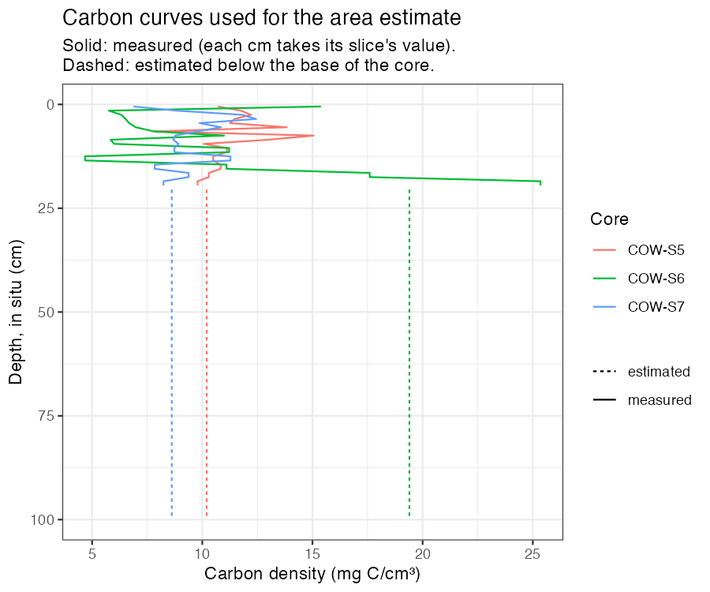

Every standard depth, and whether it could be reported.

| Depth | Status | Mean (Mg C/ha) | Total (Mg C) | Interval (Mg C/ha) | % estimated |
| --- | --- | --- | --- | --- | --- |
| 0–15 cm | measured | 14.6 | 96 | — | 0 |
| 0–30 cm | partly estimated | 33.7 | 221 | — | 38 |
| 0–50 cm | not reported |  |  | — |  |
| 0–100 cm | not reported |  |  | — |  |

## 6. Notes from the calculation

- Exploratory: the sampling units were not selected with known probabilities, so no confidence interval is reported. The spread among units is descriptive only; it does not tell you how close the mean is to the area’s true value.

## 7. Missing data, exclusions and limitations

- No cores were left out by the checks.
- The 0–30 cm scenario is 38% estimated below the cores. It assumes carbon below each core behaves like the carbon just above its base (or follows the fitted curve); deeper cores are the only way to test that.
- Compaction was not measured on some cores and was assumed to be none.
- The boundary is hypothetical, so the area and total describe no real place.

## 8. What this supports, and what would help

**Supports:** a first, descriptive figure for the average sediment organic carbon in the area and its approximate total over 0–15 cm.

**Does not support:** a confidence interval, a claim about precision, a comparison over time, or any statement about carbon being removed from the atmosphere.

**What would help:** cores placed with a random or stratified random design (Part 2), enough of them to meet the precision target, cores long enough to measure the reporting depth, and a mapped boundary.